# Practical Machine Learning - Prediction Assignment Writeup

Steffen W.

14 Januar 2018

### Course Project - Background and Goals

Recall the instructions and background from the course project. Using devices such as Jawbone Up, Nike FuelBand, and Fitbit it is now possible to collect a large amount of data about personal activity relatively inexpensively. These type of devices are part of the quantified self movement – a group of enthusiasts who take measurements about themselves regularly to improve their health, to find patterns in their behavior, or because they are tech geeks. One thing that people regularly do is quantify how much of a particular activity they do, but they rarely quantify how well they do it.

In this project the goal is to use data from accelerometers on the belt, forearm, arm, and dumbell of 6 participants and to predict the manner in which they did the exercise. They were asked to perform barbell lifts correctly and incorrectly in 5 different ways. More information is available from the website here: http://web.archive.org/web/20161224072740/http:/groupware.les.inf.puc-rio.br/har (see the section on the Weight Lifting Exercise Dataset).

#### Technical details

This is the `classe` variable in the training set. You may use any of the other variables to predict with. You should create a report describing how you built your model, how you used cross validation, what you think the expected out of sample error is, and why you made the choices you did. You will also use your prediction model to predict 20 different test cases.

The training data for this project is provided here: https://d396qusza40orc.cloudfront.net/predmachlearn/pml-training.csv

The test data is available here: https://d396qusza40orc.cloudfront.net/predmachlearn/pml-testing.csv

The data for this project comes from this source: http://web.archive.org/web/20161224072740/http:/groupware.les.inf.puc-rio.br/har

Further information is provided here including the article

**Ugulino, W.; Cardador, D.; Vega, K.; Velloso, E.; Milidiu, R.; Fuks, H. Wearable Computing: Accelerometers’ Data Classification of Body Postures and Movements. Proceedings of 21st Brazilian Symposium on Artificial Intelligence. Advances in Artificial Intelligence - SBIA 2012. In: Lecture Notes in Computer Science. , pp. 52-61. Curitiba, PR: Springer Berlin / Heidelberg, 2012. ISBN 978-3-642-34458-9. DOI: 10.1007/978-3-642-34459-6_6**

### Setup

First we setup the working directory, the libraries which will be used throughout the remaining and the seed.

```r
setwd("~/Development/Data/Coursera/PracticalMachineLearning")
library(dplyr)
library(caret)
library(corrplot)
library(rattle)
library(tidyr)
set.seed(123456789)
```

Next we load the underlying data for the project

```r
url.trainging = url("https://d396qusza40orc.cloudfront.net/predmachlearn/pml-training.csv")
url.testing   = url("https://d396qusza40orc.cloudfront.net/predmachlearn/pml-testing.csv")
training.data = read.csv(url.trainging, sep = ",", header = T)
testing.data  = read.csv(url.testing, sep = ",", header = T)
```

We will do the analysis, the model training on the `training.data` whereas the `testing.data` contains the 20 records on which we will apply the final model and prediction.

### Preprocessing - Understand and prepare the data

#### Get to know the data (level 1)

A first overview is provided by `str(training.data)`, `View(training.data)`(both too large for printing) and

```r
dim(training.data)
```

```
## [1] 19622   160
```

The data has 160 observables of which the last is `classe`. Note that many columns are of type `Factor`, consist of many `NA` records, seem to provide few variability or are used to identify the data records.

#### Prepare and clean the data

We proceed by partitioning the `training.data` into a larger training and smaller testing set

```r
idx.training = createDataPartition(training.data$classe, p = 2/3, list = F)
training.set = training.data[idx.training,]
testing.set  = training.data[-idx.training,]
```

```r
training.set.cleaned = training.set[, -c(1:7)]
```

Second we use the `nearZeroVar` to exclude the columns which provide few variability

```r
idx.nzv = nearZeroVar(training.set.cleaned, saveMetrics=T)
training.set.cleaned = training.set.cleaned[, !idx.nzv$nzv]
```

Finally let us remove the columns which consist of more than `30%` of `NA` values.

```r
contains70PctValid =
  function(col){
    col.valid = which(!is.na(col)) %>% length()
    return(col.valid >= 0.7 * length(col))
  }
idx.valid = sapply(training.set.cleaned, function(col) contains70PctValid(col) )
training.set.cleaned = training.set.cleaned[,idx.valid]
```

Note that we do not make use of `knnImpute` for the remaining `NA` values as we do not want to modify the data. We therefore end up with a trainig set of `53` observables

```r
dim(training.set.cleaned)
```

```
## [1] 13083    53
```

for which the last one is `classe` and all other columns are of type numeric or integer - see `str(training.set.cleaned)`.

Finally we apply the same procedure to the `testing.set` (but omit the prints).

#### Understand the data (level 2)

```r
preProcess(training.set.cleaned, method="pca")
```

```
## Created from 13083 samples and 53 variables
##
## Pre-processing:
##   - centered (52)
##   - ignored (1)
##   - principal component signal extraction (52)
##   - scaled (52)
##
## PCA needed 26 components to capture 95 percent of the variance
```

which is supported also by the correlation plot showing most of the observables to be uncorrelated to each other. Hence we can not perform a reduction to a few (say less than 10) significant factors.

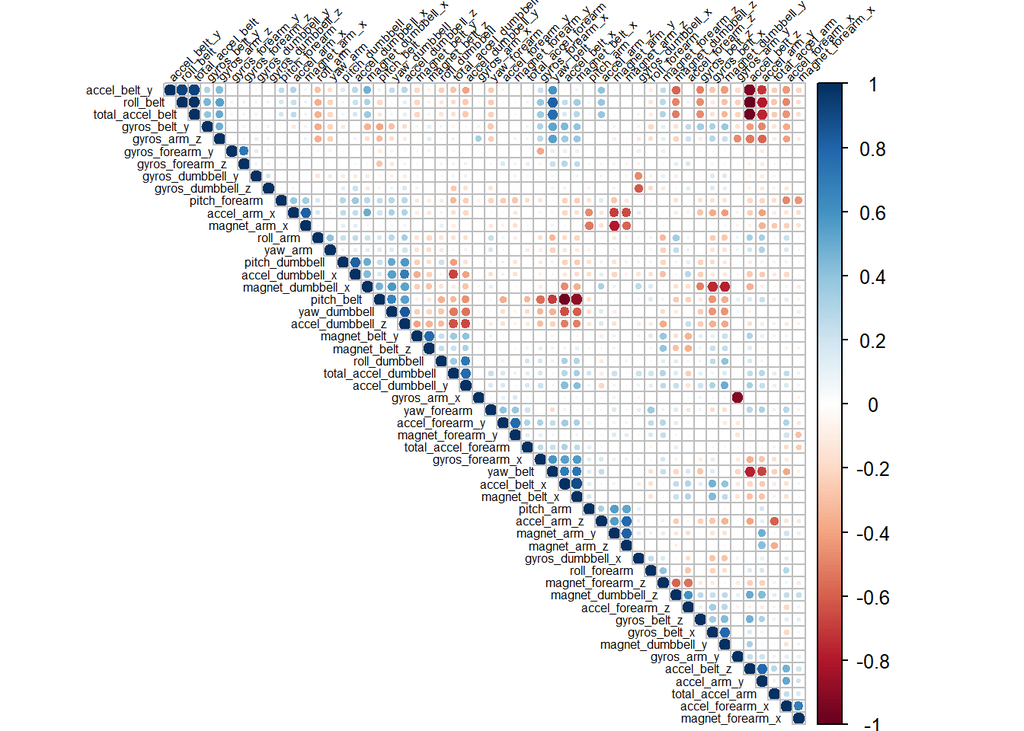

```r
corMatrix = cor(training.set.cleaned[, -53])
corrplot(corMatrix,
         type="upper", order="hclust", tl.col="black", tl.srt=45, tl.cex = 0.5,
         sig.level = 0.01, insig = "blank")
```

Further plots are not easy to provide due to the large number of potentially significant components. Finally to visualize the complexity of the data we at least provide a feature plot of the first `5` observables vs. the `classe` - it also shows a non-trivial relation between each feature and `classe`.

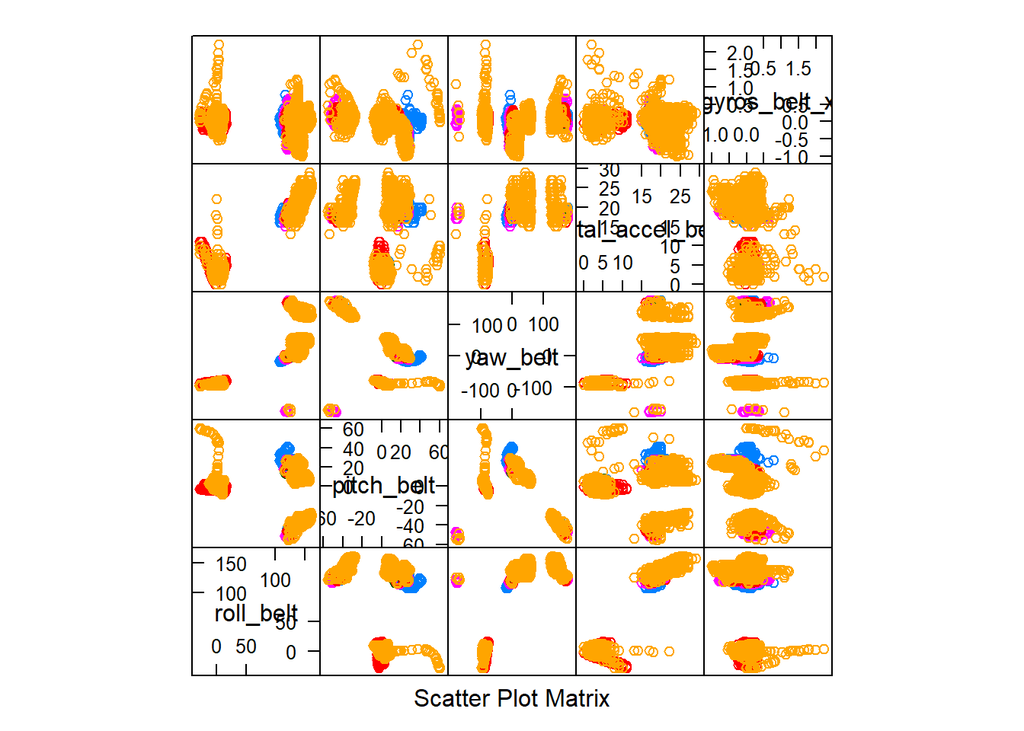

```r
featurePlot(x = training.set.cleaned[,c(1:5)],
            y = training.set.cleaned$classe,
            plot = "pairs")
```

### Models and Predictions

The outcome `classe` is of categorical type with 5 states, hence we are dealing with a classification problem. We also saw that the complexity of the data is distributed among many components. Threfore we take the following methods which we learned in class into consideration

- Decision Trees
- Random Forests
- Boosting (with trees)

#### Decision Tree

##### Model Fit

The decision tree model is trained by the method `rpart` and visualized by `rattle`’s `fancyRpartPlot` below.

```r
training.model.decisiontree = train(classe ~ ., method="rpart", data = training.set.cleaned)
print(training.model.decisiontree$finalModel)
```

```
## n= 13083
##
## node), split, n, loss, yval, (yprob)
##       * denotes terminal node
##
##  1) root 13083 9363 A (0.28 0.19 0.17 0.16 0.18)
##    2) roll_belt< 130.5 11986 8277 A (0.31 0.21 0.19 0.18 0.11)
##      4) pitch_forearm< -33.95 1055    9 A (0.99 0.0085 0 0 0) *
##      5) pitch_forearm>=-33.95 10931 8268 A (0.24 0.23 0.21 0.2 0.12)
##       10) magnet_dumbbell_y< 439.5 9271 6661 A (0.28 0.18 0.24 0.19 0.11)
##         20) roll_forearm< 123.5 5794 3450 A (0.4 0.18 0.18 0.17 0.063) *
##         21) roll_forearm>=123.5 3477 2317 C (0.077 0.18 0.33 0.23 0.18) *
##       11) magnet_dumbbell_y>=439.5 1660  808 B (0.032 0.51 0.04 0.22 0.19) *
##    3) roll_belt>=130.5 1097   11 E (0.01 0 0 0 0.99) *
```

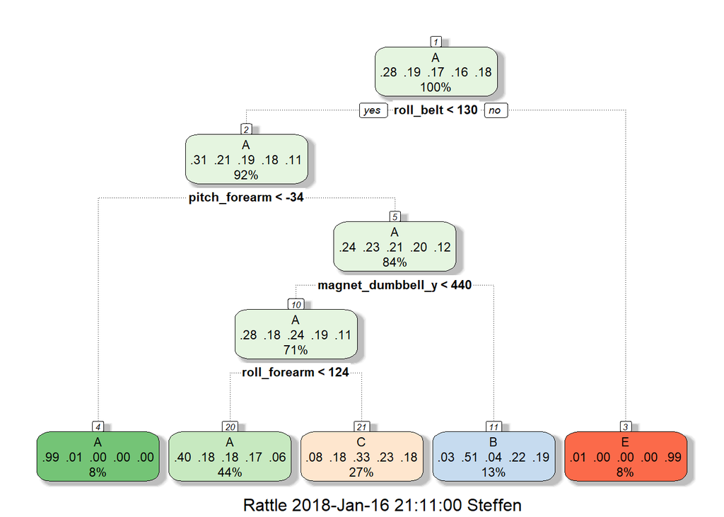

```r
fancyRpartPlot(training.model.decisiontree$finalModel)
```

##### Cross Validation

The model is applied to the testing set, the outcomes are predicted and the quality of the prediction is evaluated with the confusion matrix.

```r
testing.model.dectree.prediction = predict(training.model.decisiontree, newdata = testing.set)
confusionMatrix(testing.set$classe, testing.model.dectree.prediction)
```

```
## Confusion Matrix and Statistics
##
##           Reference
## Prediction    A    B    C    D    E
##          A 1690   28  139    0    3
##          B  511  434  320    0    0
##          C  532   41  567    0    0
##          D  480  198  394    0    0
##          E  159  168  330    0  545
##
## Overall Statistics
##
##                Accuracy : 0.4949
##                  95% CI : (0.4827, 0.5071)
##     No Information Rate : 0.5157
##     P-Value [Acc > NIR] : 0.9996
##
##                   Kappa : 0.3402
##  Mcnemar's Test P-Value : NA
##
## Statistics by Class:
##
##                      Class: A Class: B Class: C Class: D Class: E
## Sensitivity            0.5012  0.49942  0.32400       NA  0.99453
## Specificity            0.9463  0.85344  0.88035   0.8361  0.89034
## Pos Pred Value         0.9086  0.34308  0.49737       NA  0.45341
## Neg Pred Value         0.6405  0.91752  0.78089       NA  0.99944
## Prevalence             0.5157  0.13289  0.26763   0.0000  0.08380
## Detection Rate         0.2584  0.06637  0.08671   0.0000  0.08335
## Detection Prevalence   0.2844  0.19345  0.17434   0.1639  0.18382
## Balanced Accuracy      0.7238  0.67643  0.60218       NA  0.94243
```

##### Conclusion

The results - **accuracy of roughly `50%`** - are not very promising, not to say useless, and we reject the model for the predicition.

#### Random Forest

##### Model Fit

The random forest model is trained by the method `rf` (without tuning parameters `proxy = T` since the computation took too long) and the most important components are presented below.

```r
training.model.randomforest = train(classe ~ ., method="rf", trControl = trainControl(method = "cv", number = 4), data=training.set.cleaned)
# training.model.randomforest = train(classe ~ ., method="rf", proxy = T, data=training.set.cleaned)
print(training.model.randomforest$finalModel)
```

```
##
## Call:
##  randomForest(x = x, y = y, mtry = param$mtry)
##                Type of random forest: classification
##                      Number of trees: 500
## No. of variables tried at each split: 2
##
##         OOB estimate of  error rate: 0.83%
## Confusion matrix:
##      A    B    C    D    E  class.error
## A 3717    3    0    0    0 0.0008064516
## B   16 2506   10    0    0 0.0102685624
## C    0   19 2259    4    0 0.0100788782
## D    0    0   45 2096    3 0.0223880597
## E    0    0    1    7 2397 0.0033264033
```

```r
varImp(training.model.randomforest)
```

```
## rf variable importance
##
##   only 20 most important variables shown (out of 52)
##
##                      Overall
## roll_belt             100.00
## yaw_belt               83.72
## magnet_dumbbell_z      75.12
## magnet_dumbbell_y      66.88
## pitch_belt             66.47
## pitch_forearm          56.83
## magnet_dumbbell_x      55.83
## roll_forearm           54.17
## accel_belt_z           50.27
## magnet_belt_z          46.81
## roll_dumbbell          45.72
## magnet_belt_y          44.94
## accel_dumbbell_y       42.43
## accel_dumbbell_z       37.75
## roll_arm               36.70
## accel_forearm_x        33.68
## total_accel_dumbbell   31.36
## gyros_belt_z           30.37
## accel_arm_x            30.23
## accel_dumbbell_x       30.10
```

##### Cross Validation

The model is applied to the testing set, the outcomes are predicted and the quality of the prediction is evaluated with the confusion matrix.

```r
testing.model.randomforest.prediction = predict(training.model.randomforest, newdata = testing.set)
confusionMatrix(testing.set$classe, testing.model.randomforest.prediction)
```

```
## Confusion Matrix and Statistics
##
##           Reference
## Prediction    A    B    C    D    E
##          A 1860    0    0    0    0
##          B    4 1257    4    0    0
##          C    0   11 1128    1    0
##          D    0    0   18 1052    2
##          E    0    0    0    2 1200
##
## Overall Statistics
##
##                Accuracy : 0.9936
##                  95% CI : (0.9913, 0.9954)
##     No Information Rate : 0.2851
##     P-Value [Acc > NIR] : < 2.2e-16
##
##                   Kappa : 0.9919
##  Mcnemar's Test P-Value : NA
##
## Statistics by Class:
##
##                      Class: A Class: B Class: C Class: D Class: E
## Sensitivity            0.9979   0.9913   0.9809   0.9972   0.9983
## Specificity            1.0000   0.9985   0.9978   0.9964   0.9996
## Pos Pred Value         1.0000   0.9937   0.9895   0.9813   0.9983
## Neg Pred Value         0.9991   0.9979   0.9959   0.9995   0.9996
## Prevalence             0.2851   0.1939   0.1759   0.1613   0.1838
## Detection Rate         0.2844   0.1922   0.1725   0.1609   0.1835
## Detection Prevalence   0.2844   0.1935   0.1743   0.1639   0.1838
## Balanced Accuracy      0.9989   0.9949   0.9893   0.9968   0.9990
```

##### Conclusion

The results - **accuracy of roughly `99%`** - are very promising and we accept the model for the final prediction. The high accuracy might even lead to the conclusion of over fitting.

#### Boosting

We chose to not document the results in order to keep it short - the results were similiar (but slightly worse) to the randon forest method.

### Final prediction - out of sample

#### Predictions

In this final section we apply the random forest model in the final prediction to the 20 records of the `testing.data` and predict the outcomes for `classe` as follows.

```r
predict(training.model.randomforest, newdata=testing.data)
```

```
##  [1] B A B A A E D B A A B C B A E E A B B B
## Levels: A B C D E
```

The predictions turned out to be all correct.

#### Final Conclusion

We performed the whole process of getting the data, preprocessing the data, fitting the model and predicting the outcomes as well as interpreting the results, as we learned it in the class of `Practical Machine Learning`. The goal was to predict categorical outcomes for which we analysed the data and some of the relevant methods we learned in class. Eventually we chose the random forest model for the final prediction which we almost suspected to be over fitted due to the high accuracy on the test set. However the final predictions turned out to be all correct.